# Setting up Nettskjema API authentication

To set up a connection to the Nettskjema API, you need to create an api-user, and a token associated with this user. The nettskjema api-user is different from your standard user that has access to nettskjema. This is a specific user that may access nettskjema through the API.

Use the `nettskjema_user_create` function to be routed to the portal to set this up.

```r
library(nettskjemar)
```

```r
nettskjema_user_create()
```

Create an api user, I recommend using your uio user name or an UiO user group.

[figure not shown]

Click on the created username to access the token generation.

[figure not shown]

Select which permissions the token should be allowed to have, and save to create the token.

[figure not shown]

Copy the token and return to RStudio (this example token has been deleted).

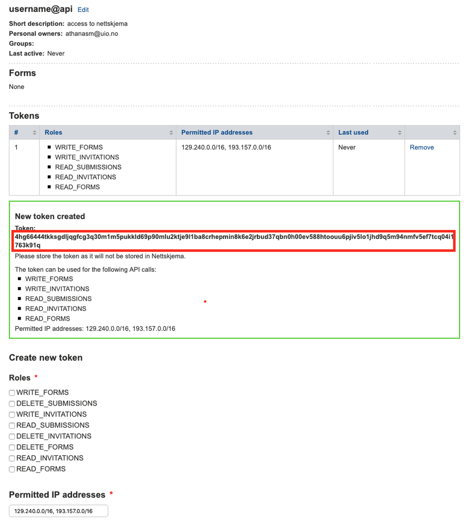

In R, you can now add this token to your `.Renviron` file.

You can do this in one of two ways, either open the file with `nettskjema_renviron_edit()`,

```bash
NETTSKJEMA_API_TOKEN=paste_token_here
```

or add it directly with:

```r
nettskjema_token2renviron("paste_token_here")
```

This will add the token to the environment variable `NETTSKJEMA_API_TOKEN`. If you want to give the token another name, or you have several tokens and need to store them separately, you can do so:

```r
nettskjema_token2renviron("paste_token_here",
                          token_name = "ANOTHER_NAME")
```

This function will add the token so you can authenticate your self to nettskjema, and also make sure the `.Renviron` file is locked so no other user of your computer may access it. Fot it to take effect, you need your R session to restart. You may do so in RStudio by going to `Session` -> `Restart R session`, og by pressing `cmd/ctrl + shift + F10` on the keyboard.

This token is important to keep safe. If you believe the token has been compromised in any way, delete it in the API user-portal and create a new one.

## Check token expiry date

The token is valid for 1 year. You can check the remaining time left a token is valid by

```r
nettskjema_token_expiry()
```

```
Token with name 'NETTSKJEMA_API_TOKEN' expires in 292 days.
[1] "2022-02-26"
```